# Fama–MacBeth regression

Given data on risk factors and portfolio returns, it is useful to estimate the portfolio's exposure, or how much a risk factor is driving portfolio returns, as well as how much is the exposure to a given risk factor worth. What is the market's risk factor premium?

The risk premium then permits to estimate the return for any portfolio provided the factor exposure is known or can be estimated.

Inference problems will likely arise in such cross-sectional regressions because the fundamental assumptions of classical linear regression may not hold. Potential violations include measurement errors, covariation of residuals due to heteroskedasticity and serial correlation, and multicollinearity.

To address the inference problem caused by the correlation of the residuals, `Fama and MacBeth` proposed a two step methodology for a cross-sectional regression of returns on risk factors. The two-stage `Fama—Macbeth regression` is designed to estimate the premium rewarded for the exposure to a particular risk factor by the market. The two stages consist of:

- **First stage:** `N` time-series regression, one for each asset or portfolio, of its excess returns on the factors to estimate the factor loadings. In matrix form, for each asset:

[figure not shown]

- **Second stage:** `T` cross-sectional regression, one for each time period, to estimate the risk premium. In matrix form, we obtain a vector $\hat{\lambda_t}$ of risk premia for each period:

[figure not shown]

Now we can compute the factor risk premia as the time average and get `t-statistic` to assess their individual significance, using the assumption that the risk premia estimates are independent over time:

$$t = \frac{\lambda_j}{\alpha(\lambda_j) \div \sqrt{(T)}}$$

## Why build a linear factor model?

Algorithmic trading strategies use linear factor models to quantify the relationship between the return of an asset and the sources of risk that represent the main drivers of these returns. Each factor risk carries a premium, and the total asset return can be expected to correspond to a weighted average of these risk premia.

There are several practical applications of factor models across the portfolio management process from construction and asset selection to risk management and performance evaluation. The importance of factor models continues to grow as common risk factors are now tradeable:

- A summary of the returns of many assets by a much smaller number of factors reduces the amount of data required to estimate the covariance matrix when optimizing a portfolio
- An estimate of the exposure of an asset or a portfolio to these factors allows for the management of the resultant risk, for instance by entering suitable hedges when risk factors are themselves traded
- A factor model also permits the assessment of the incremental signal content of new alpha factors
- A factor model can also help assess whether a manager's performance relative to a benchmark is indeed due to skill in selecting assets and timing the market, or if instead, the performance can be explained by portfolio tilts towards known return drivers that can today be replicated as low-cost, passively managed funds without incurring active management fees

# Imports

```python
from pprint import pprint
import numpy as np
import pandas as pd
import pyfolio as pf
import quantstats as qs
from datetime import date
from pandas_datareader.famafrench import get_available_datasets
from scipy.stats import spearmanr, pearsonr
import pandas as pd
import numpy as np
import matplotlib.pyplot as plt
import matplotlib.cm as cm
from statsmodels.api import OLS, add_constant
from pathlib import Path
from linearmodels.asset_pricing import TradedFactorModel, LinearFactorModel, LinearFactorModelGMM
import nance_db
```

```python
import seaborn as sns
from pandas_datareader import data as web
import warnings
warnings.filterwarnings('ignore')
pd.set_option('display.max_columns', None)
pd.set_option('display.max_rows', 500)
```

## Get Data

`Fama and French` make updated risk factor and research portfolio data available through their [website](http://mba.tuck.dartmouth.edu/pages/faculty/ken.french/data_library.html), and you can use the `pandas_datareader` package to obtain the data.

### Risk Factors

| Label | Name | Description |
| --- | --- | --- |
| SMB | Small Minus Big | Average return on the nine small stock portfolios minus the average return on the nine big stock portfolios |
| HML | High Minus Low | Average return on the two value portfolios minus the average return on the two growth portfolios |
| RMW | Robust minus Weak | Average return on the two robust operating profitability portfolios minus the average return on the two weak operating profitability portfolios |
| CMA | Conservative Minus Aggressive | Average return on the two conservative investment portfolios minus the average return on the two aggressive investment portfolios |
| Rm-Rf | Excess return on the market | Value-weight return of all firms incorporated in the US and listed on the NYSE, AMEX, or NASDAQ at the beginning of month t with 'good' data for t minus the one-month Treasury bill rate |

The `Fama-French` `5` factors are based on the `6` value-weight portfolios formed on size and book-to-market, the `6` value-weight portfolios formed on size and operating profitability, and the 6 value-weight portfolios formed on size and investment.

We will use returns at a monthly frequency that we obtain for the period `2010 – 2020` as follows:

```python
start = pd.Timestamp('2010')
end = pd.Timestamp('2020-02')

ff_factor = 'F-F_Research_Data_5_Factors_2x3'
ff_factor_data = web.DataReader(ff_factor, 'famafrench', start=start, end=end)[0]
ff_factor_data.info()
```

```
<class 'pandas.core.frame.DataFrame'>
PeriodIndex: 121 entries, 2010-01 to 2020-01
Freq: M
Data columns (total 6 columns):
Mkt-RF    121 non-null float64
SMB       121 non-null float64
HML       121 non-null float64
RMW       121 non-null float64
CMA       121 non-null float64
RF        121 non-null float64
dtypes: float64(6)
memory usage: 6.6 KB
```

```python
ff_factor_data.describe()
```

|  | Mkt-RF | SMB | HML | RMW | CMA | RF |
| --- | --- | --- | --- | --- | --- | --- |
| count | 121.000000 | 121.000000 | 121.000000 | 121.000000 | 121.000000 | 121.000000 |
| mean | 1.081488 | -0.068182 | -0.266198 | 0.127190 | -0.001322 | 0.043388 |
| std | 3.730119 | 2.330899 | 2.343518 | 1.459477 | 1.456330 | 0.065340 |
| min | -9.550000 | -4.550000 | -6.260000 | -3.990000 | -3.330000 | 0.000000 |
| 25% | -0.850000 | -1.890000 | -1.810000 | -0.730000 | -1.080000 | 0.000000 |
| 50% | 1.290000 | 0.210000 | -0.340000 | 0.170000 | -0.020000 | 0.010000 |
| 75% | 3.400000 | 1.330000 | 0.950000 | 1.100000 | 0.910000 | 0.070000 |
| max | 11.350000 | 6.810000 | 8.290000 | 3.480000 | 3.700000 | 0.210000 |

### Portfolios

`Fama and French` also make numerous portfolios that we can illustrate the estimation of the risk factor exposures, as well as the value of the risk premia available in the market for a given time period. We will use a panel of the `17` industry portfolios at a monthly frequency.

We will subtract the risk-free rate from the returns because the factor model works with excess returns:

```python
ff_portfolio = '17_Industry_Portfolios'
ff_portfolio_data = web.DataReader(ff_portfolio, 'famafrench', start=start, end=end)[0]
ff_portfolio_data = ff_portfolio_data.sub(ff_factor_data.RF, axis=0)
ff_portfolio_data.info()
```

```
<class 'pandas.core.frame.DataFrame'>
PeriodIndex: 121 entries, 2010-01 to 2020-01
Freq: M
Data columns (total 17 columns):
Food     121 non-null float64
Mines    121 non-null float64
Oil      121 non-null float64
Clths    121 non-null float64
Durbl    121 non-null float64
Chems    121 non-null float64
Cnsum    121 non-null float64
Cnstr    121 non-null float64
Steel    121 non-null float64
FabPr    121 non-null float64
Machn    121 non-null float64
Cars     121 non-null float64
Trans    121 non-null float64
Utils    121 non-null float64
Rtail    121 non-null float64
Finan    121 non-null float64
Other    121 non-null float64
dtypes: float64(17)
memory usage: 17.0 KB
```

# Equity Data

[Vanguard](https://investor.vanguard.com/etf/list#/etf/asset-class/month-end-returns) Sector & specialty ETFs

```python
symbols = ['VOX', 'VCR', 'VDC', 'VDE', 'VFH', 'VHT', 'VIS', 'VGT', 'VAW', 'VNQ', 'VPU']
secs = ['COMM', 'CONSUMER DISC', 'CONSUMER ST', 'ENERGY', 'FINANCIALS', 'HEALTH', 'INDUSTRIALS',
           'TECHNOLOGY', 'MATIREALS', 'REAL ESTATE', 'UTILITIES']
```

```python
def get_symbols(symbols,data_source,ohlc,begin_date=None,end_date=None):
    out = []
    new_symbols = []

    for symbol in symbols:
        df = web.DataReader(symbol, data_source,begin_date, end_date)\
        [['High','Low','Open','Close','Volume','Adj Close']]
        new_symbols.append(symbol)
        out.append(df[ohlc].astype('float'))
        data = pd.concat(out, axis = 1)
        data.columns = new_symbols

    return data
```

```python
prices = get_symbols(symbols,data_source='yahoo',ohlc='Close',\
                     begin_date=start,end_date=end)

SPY = web.DataReader('SPY', 'yahoo', start, end)\
      [['High','Low','Open','Close','Volume','Adj Close']]
```

```python
prices.columns = secs
prices['SPY'] = SPY.Close.values
prices.info()
```

```
<class 'pandas.core.frame.DataFrame'>
DatetimeIndex: 2537 entries, 2010-01-04 to 2020-01-31
Data columns (total 12 columns):
COMM             2537 non-null float64
CONSUMER DISC    2537 non-null float64
CONSUMER ST      2537 non-null float64
ENERGY           2537 non-null float64
FINANCIALS       2537 non-null float64
HEALTH           2537 non-null float64
INDUSTRIALS      2537 non-null float64
TECHNOLOGY       2537 non-null float64
MATIREALS        2537 non-null float64
REAL ESTATE      2537 non-null float64
UTILITIES        2537 non-null float64
SPY              2537 non-null float64
dtypes: float64(12)
memory usage: 257.7 KB
```

```python
returns0 = prices.pct_change()
returns0 = returns0.dropna(how='all').dropna(axis=1)
```

# EDA

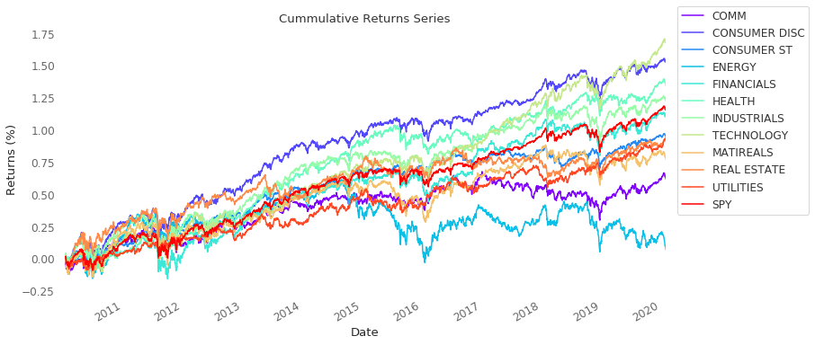

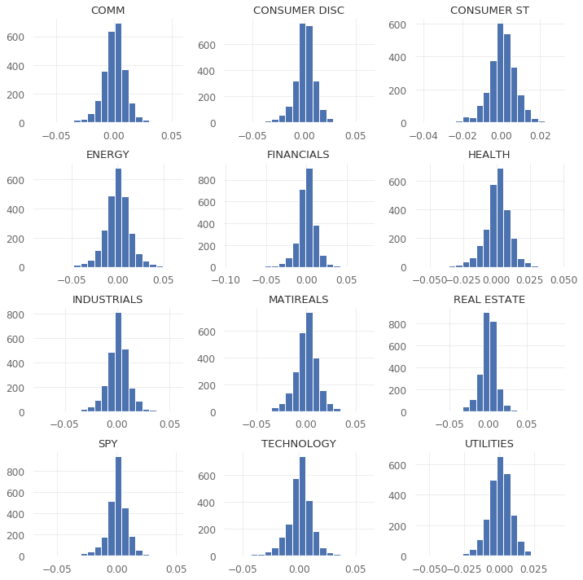

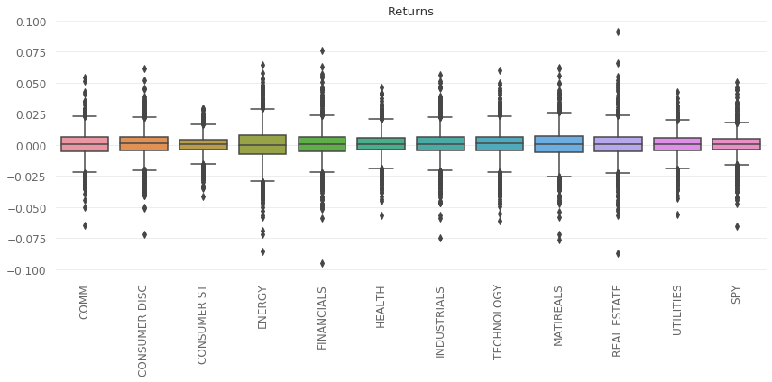

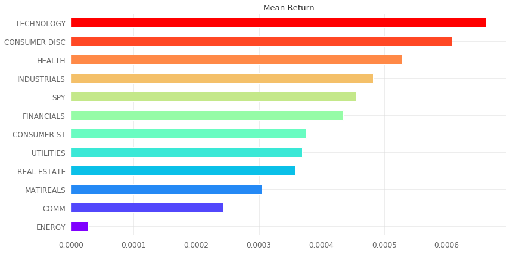

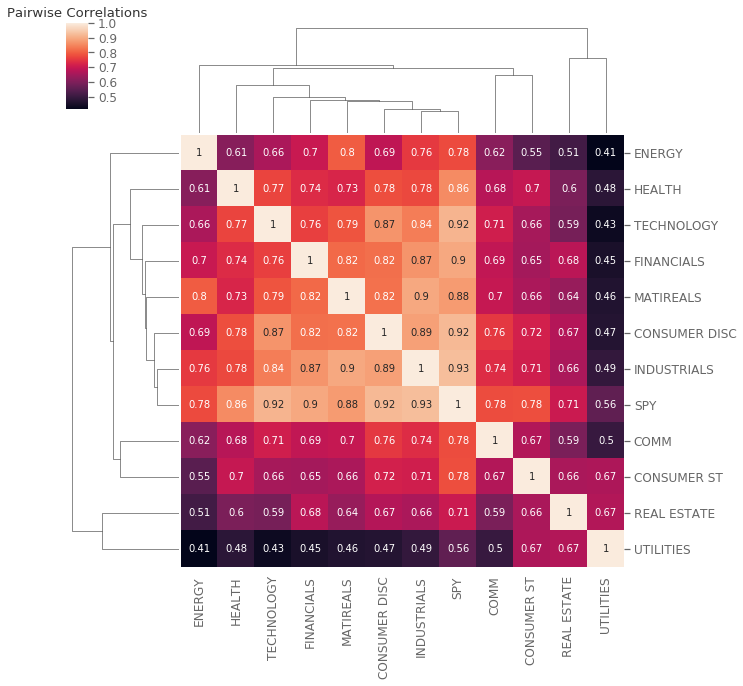

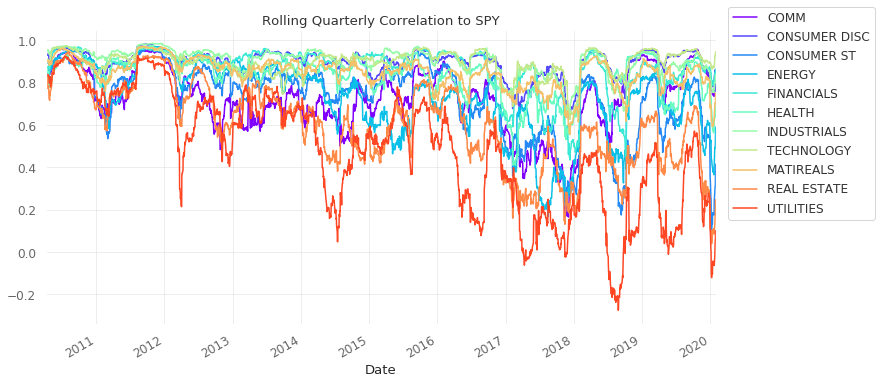

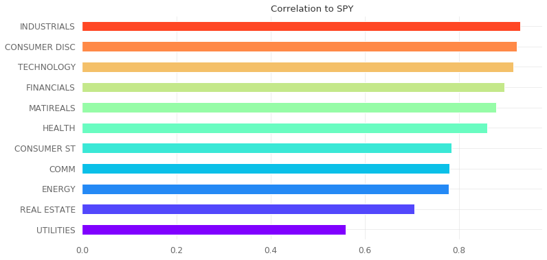

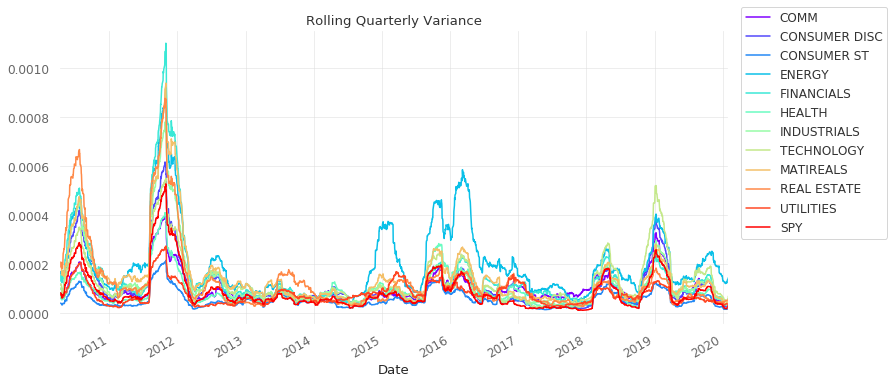

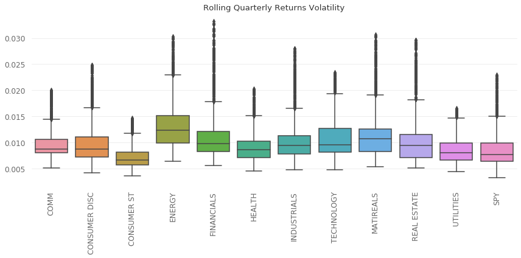

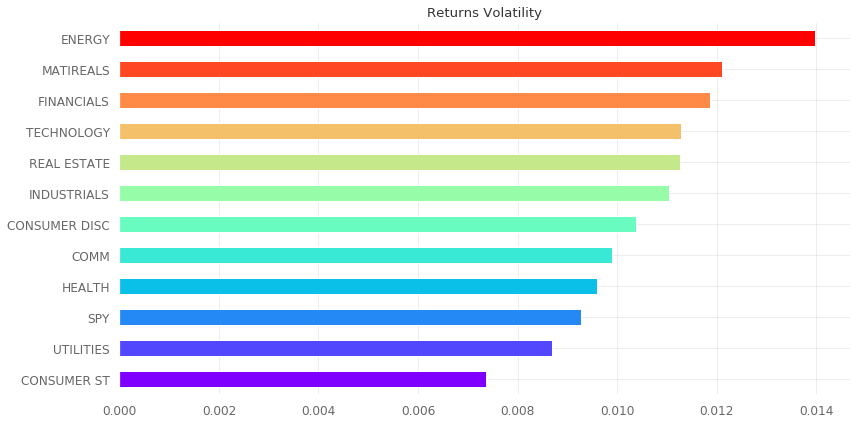

```python
pricesx = returns0.copy()

n_secs = len(pricesx.columns)
colors = cm.rainbow(np.linspace(0, 1, n_secs))
pricesx.cumsum().plot(color=colors, figsize=(12, 6))# Normalize Prices
plt.title('Cummulative Returns Series')
plt.xlabel('Date')
plt.ylabel('Returns (%)')
plt.grid(b=None, which=u'major', axis=u'both')
plt.legend(bbox_to_anchor=(1.01, 1.1), loc='upper left', ncol=1)
plt.show();

pricesx.hist(bins=20, figsize=(10,10))
plt.tight_layout()
plt.show()

plt.figure(figsize=(12,6))
g1 = sns.boxplot(data=pricesx)
g1.set_xticklabels(g1.get_xticklabels(),rotation=90)
plt.title('Returns')
plt.tight_layout()
plt.show()

plt.figure(figsize=(12,6))
pricesx.mean().sort_values(ascending=True).plot(kind='barh',colors=colors)
plt.title('Mean Return')
plt.tight_layout()
plt.show()

g = sns.clustermap(pricesx.corr(), annot=True)
ax = g.ax_heatmap
bottom, top = ax.get_ylim()
ax.set_ylim(bottom + 0.5, top - 0.5)
plt.title('Pairwise Correlations')
plt.show()

pricesx.drop('SPY', axis=1).rolling(63).corr(pricesx.SPY).dropna().plot(color=colors, figsize=(12, 6))
plt.legend(bbox_to_anchor=(1.01, 1.1), loc='upper left', ncol=1)
plt.title('Rolling Quarterly Correlation to SPY')
plt.show()

pricesx.drop('SPY',axis=1).corrwith(pricesx.SPY).sort_values(ascending=True).plot(kind='barh', color=colors, figsize=(12, 6))
plt.title('Correlation to SPY')
plt.show()

pricesx.rolling(63).var().dropna().plot(color=colors, figsize=(12, 6))
plt.legend(bbox_to_anchor=(1.01, 1.1), loc='upper left', ncol=1)
plt.title('Rolling Quarterly Variance')
plt.show()

plt.figure(figsize=(12,6))
g2 = sns.boxplot(data=pricesx.rolling(63).std().dropna())
g2.set_xticklabels(g2.get_xticklabels(),rotation=90)
plt.title('Rolling Quarterly Returns Volatility')
plt.tight_layout()
plt.show()

plt.figure(figsize=(12,6))
pricesx.std().sort_values(ascending=True).plot(kind='barh',colors=colors)
plt.title('Returns Volatility')
plt.tight_layout()
plt.show()
```

```python
def r2(x, y):
    return pearsonr(x, y)[0] ** 2
```

```python
tmp_fts = pricesx.copy()
```

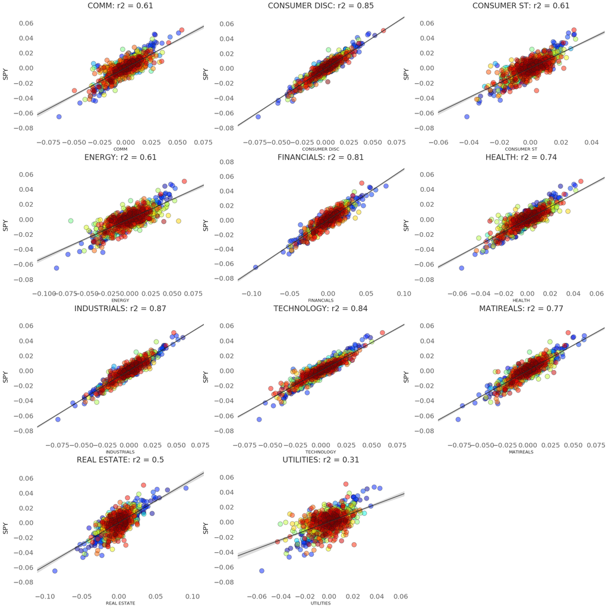

```python
fig, axs = plt.subplots(ncols=2, nrows=0, figsize=(10, 40))
plt.subplots_adjust(right=2.5)
plt.subplots_adjust(top=2)

cm = plt.get_cmap('jet')
colors = np.linspace(0.1, 1, len(tmp_fts))

for i, feature in enumerate(list(tmp_fts), 1):
    if(feature=='SPY'):
        break

    ic, pval = spearmanr(tmp_fts[feature], tmp_fts['SPY'])
    R2 = r2(tmp_fts[feature], tmp_fts['SPY'])

    plt.subplot(len(list(tmp_fts.columns)), 3, i)
    sc = plt.scatter(tmp_fts[feature], tmp_fts['SPY'], s=200,
                 edgecolor='k', alpha=0.5, label='Price Data', c=colors, cmap=cm)
    j = sns.regplot(tmp_fts[feature], tmp_fts['SPY'], data=tmp_fts, scatter=False, label=False,
                line_kws={'color':'k','lw':2.5, 'alpha':0.65})

    plt.ylabel('SPY', size=23, labelpad=14, fontsize=20, fontweight='medium')

    plt.title(f'{feature}: r2 = {round(R2,2)}', fontsize=23, fontweight='medium')
    plt.grid(False)

    for j in range(2):
        plt.tick_params(axis='x', labelsize=20)
        plt.tick_params(axis='y', labelsize=20)

plt.show()
```

```python
returns = prices.resample('M').last().pct_change().mul(100).to_period('M')
returns = returns.dropna(how='all').dropna(axis=1)
returns.info()
```

```
<class 'pandas.core.frame.DataFrame'>
PeriodIndex: 120 entries, 2010-02 to 2020-01
Freq: M
Data columns (total 12 columns):
COMM             120 non-null float64
CONSUMER DISC    120 non-null float64
CONSUMER ST      120 non-null float64
ENERGY           120 non-null float64
FINANCIALS       120 non-null float64
HEALTH           120 non-null float64
INDUSTRIALS      120 non-null float64
TECHNOLOGY       120 non-null float64
MATIREALS        120 non-null float64
REAL ESTATE      120 non-null float64
UTILITIES        120 non-null float64
SPY              120 non-null float64
dtypes: float64(12)
memory usage: 12.2 KB
```

### Align data

```python
ff_factor_data = ff_factor_data.loc[returns.index]
ff_portfolio_data = ff_portfolio_data.loc[returns.index]
```

```python
ff_factor_data.describe()
```

|  | Mkt-RF | SMB | HML | RMW | CMA | RF |
| --- | --- | --- | --- | --- | --- | --- |
| count | 120.00000 | 120.000000 | 120.000000 | 120.000000 | 120.000000 | 120.000000 |
| mean | 1.11850 | -0.071167 | -0.270917 | 0.139833 | -0.005167 | 0.043750 |
| std | 3.72338 | 2.340440 | 2.352767 | 1.458927 | 1.461820 | 0.065492 |
| min | -9.55000 | -4.550000 | -6.260000 | -3.990000 | -3.330000 | 0.000000 |
| 25% | -0.42250 | -1.895000 | -1.810000 | -0.715000 | -1.085000 | 0.000000 |
| 50% | 1.32500 | 0.180000 | -0.370000 | 0.190000 | -0.025000 | 0.010000 |
| 75% | 3.40000 | 1.335000 | 0.987500 | 1.102500 | 0.920000 | 0.072500 |
| max | 11.35000 | 6.810000 | 8.290000 | 3.480000 | 3.700000 | 0.210000 |

### Compute excess Returns

```python
excess_returns = returns.sub(ff_factor_data.RF, axis=0)
excess_returns.info()
```

```
<class 'pandas.core.frame.DataFrame'>
PeriodIndex: 120 entries, 2010-02 to 2020-01
Freq: M
Data columns (total 12 columns):
COMM             120 non-null float64
CONSUMER DISC    120 non-null float64
CONSUMER ST      120 non-null float64
ENERGY           120 non-null float64
FINANCIALS       120 non-null float64
HEALTH           120 non-null float64
INDUSTRIALS      120 non-null float64
TECHNOLOGY       120 non-null float64
MATIREALS        120 non-null float64
REAL ESTATE      120 non-null float64
UTILITIES        120 non-null float64
SPY              120 non-null float64
dtypes: float64(12)
memory usage: 12.2 KB
```

```python
excess_returns = excess_returns.clip(lower=np.percentile(excess_returns, 1),
                                     upper=np.percentile(excess_returns, 99))
```

## Fama-Macbeth Regression

Given data on risk factors and portfolio returns, it is useful to estimate the portfolio's exposure, that is, how much the risk factors drive portfolio returns, as well as how much the exposure to a given factor is worth, that is, the what market's risk factor premium is. The risk premium then permits to estimate the return for any portfolio provided the factor exposure is known or can be assumed.

```python
ff_portfolio_data.info()
```

```
<class 'pandas.core.frame.DataFrame'>
PeriodIndex: 120 entries, 2010-02 to 2020-01
Freq: M
Data columns (total 17 columns):
Food     120 non-null float64
Mines    120 non-null float64
Oil      120 non-null float64
Clths    120 non-null float64
Durbl    120 non-null float64
Chems    120 non-null float64
Cnsum    120 non-null float64
Cnstr    120 non-null float64
Steel    120 non-null float64
FabPr    120 non-null float64
Machn    120 non-null float64
Cars     120 non-null float64
Trans    120 non-null float64
Utils    120 non-null float64
Rtail    120 non-null float64
Finan    120 non-null float64
Other    120 non-null float64
dtypes: float64(17)
memory usage: 16.9 KB
```

```python
ff_factor_data.info()
```

```
<class 'pandas.core.frame.DataFrame'>
PeriodIndex: 120 entries, 2010-02 to 2020-01
Freq: M
Data columns (total 6 columns):
Mkt-RF    120 non-null float64
SMB       120 non-null float64
HML       120 non-null float64
RMW       120 non-null float64
CMA       120 non-null float64
RF        120 non-null float64
dtypes: float64(6)
memory usage: 6.6 KB
```

### Factor Exposures

We can implement the first stage to obtain the `17` factor loading estimates as follows:

```python
from statsmodels.api import OLS, add_constant

betas = []
for industry in ff_portfolio_data:
    step1 = OLS(endog=ff_portfolio_data.loc[ff_factor_data.index, industry],
                exog=add_constant(ff_factor_data)).fit()
    betas.append(step1.params.drop('const'))
```

```python
betas = pd.DataFrame(betas,
                     columns=ff_factor_data.columns,
                     index=ff_portfolio_data.columns)
betas.info()
```

```
<class 'pandas.core.frame.DataFrame'>
Index: 17 entries, Food  to Other
Data columns (total 6 columns):
Mkt-RF    17 non-null float64
SMB       17 non-null float64
HML       17 non-null float64
RMW       17 non-null float64
CMA       17 non-null float64
RF        17 non-null float64
dtypes: float64(6)
memory usage: 1.6+ KB
```

### Risk Premia

For the second stage, we run `120` regressions of the period returns for the cross section of portfolios on the factor loadings

```python
lambdas = []
for period in ff_portfolio_data.index:
    step2 = OLS(endog=ff_portfolio_data.loc[period, betas.index],
                exog=betas).fit()
    lambdas.append(step2.params)
```

```python
lambdas = pd.DataFrame(lambdas,
                       index=ff_portfolio_data.index,
                       columns=betas.columns.tolist())
lambdas.info()
```

```
<class 'pandas.core.frame.DataFrame'>
PeriodIndex: 120 entries, 2010-02 to 2020-01
Freq: M
Data columns (total 6 columns):
Mkt-RF    120 non-null float64
SMB       120 non-null float64
HML       120 non-null float64
RMW       120 non-null float64
CMA       120 non-null float64
RF        120 non-null float64
dtypes: float64(6)
memory usage: 17.5 KB
```

```python
lambdas.mean()
```

```
Mkt-RF    1.214513
SMB      -0.255973
HML      -1.424541
RMW      -0.289188
CMA      -0.783443
RF        0.003422
dtype: float64
```

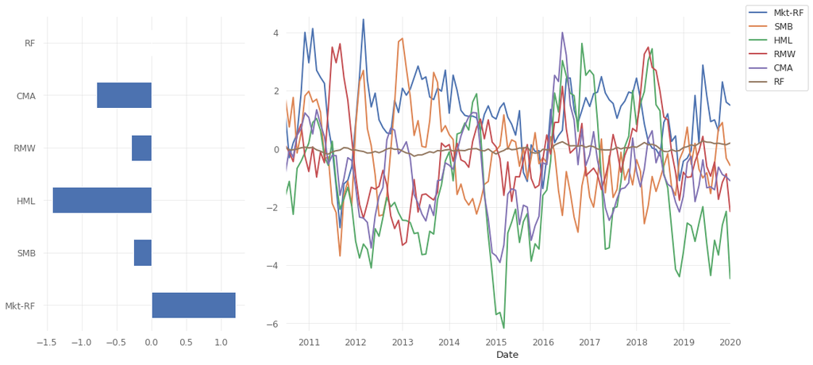

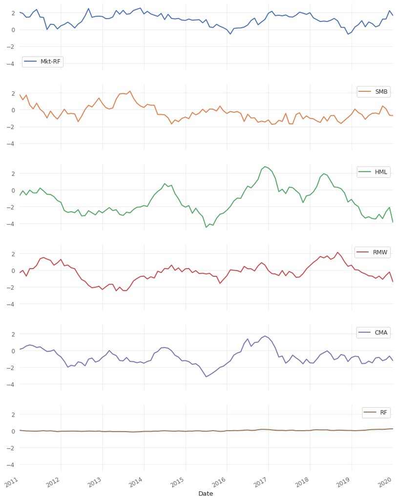

```python
ax1 = plt.subplot2grid((1, 3), (0, 0))
ax2 = plt.subplot2grid((1, 3), (0, 1), colspan=2)
ax2.margins(0.01)
lambdas.mean().plot.barh(ax=ax1)
lambdas0 = lambdas.rolling(6).mean().dropna()
lambdas0.plot(lw=2, figsize=(17,8), ax=ax2)
ax2.legend(bbox_to_anchor=(1.025, 1.05))
plt.show()

lambdas.rolling(12).mean().dropna().plot(lw=2, figsize=(14,20), subplots=True, sharey=True, sharex=True)
plt.show()
```

## Fama-Macbeth with the LinearModels library

The linear_models library extends statsmodels with various models for panel data and also implements the two-stage Fama—MacBeth procedure:

```python
from linearmodels.asset_pricing import TradedFactorModel, LinearFactorModel, LinearFactorModelGMM

mod = LinearFactorModel(portfolios=ff_portfolio_data,
                        factors=ff_factor_data)
res = mod.fit(cov_type='robust')
print(res.summary)
```

```
                      LinearFactorModel Estimation Summary
================================================================================
No. Test Portfolios:                 17   R-squared:                      0.7045
No. Factors:                          6   J-statistic:                    16.921
No. Observations:                   120   P-value                         0.1102
Date:                  Fri, Mar 06 2020   Distribution:                 chi2(11)
Time:                          16:16:16
Cov. Estimator:                  robust

                            Risk Premia Estimates
==============================================================================
            Parameter  Std. Err.     T-stat    P-value    Lower CI    Upper CI
------------------------------------------------------------------------------
Mkt-RF         1.2145     0.3713     3.2713     0.0011      0.4869      1.9422
SMB           -0.2560     0.8299    -0.3084     0.7578     -1.8826      1.3707
HML           -1.4245     0.6622    -2.1514     0.0314     -2.7223     -0.1267
RMW           -0.2892     0.7010    -0.4125     0.6800     -1.6632      1.0848
CMA           -0.7834     0.3770    -2.0780     0.0377     -1.5224     -0.0445
RF             0.0034     0.0560     0.0611     0.9513     -0.1063      0.1131
==============================================================================

Covariance estimator:
HeteroskedasticCovariance
See full_summary for complete results
```

This provides us with the same result:

```python
lambdas.mean()
```

```
Mkt-RF    1.214513
SMB      -0.255973
HML      -1.424541
RMW      -0.289188
CMA      -0.783443
RF        0.003422
dtype: float64
```